# Ejercicio: Datos satelitales en GRASS GIS

Autor/a

Verónica Andreo

Fecha de publicación

12 de septiembre de 2023

En este ejercicio, trabajaremos con imágenes del satélite Sentinel 2 en GRASS GIS. Vamos a recorrer algunos módulos específicos para la búsqueda, descarga e importación de datos Sentinel, abordar los diferentes pasos a seguir en función del nivel de procesamiento, enmascarar nubes y sombras de nubes, realizar segmentaciones y clasificaciones supervisadas.

Antes de empezar y para ganar tiempo, conectamos nuestro drive e instalamos GRASS en Google Colab.

```python
# import drive from google colab
from google.colab import drive
# mount drive
drive.mount("/content/drive")
```

```python
%%bash
DEBIAN_FRONTEND=noninteractive
sudo add-apt-repository ppa:ubuntugis/ubuntugis-unstable
apt update
apt install grass subversion grass-dev
apt remove libproj22
```

Chequeamos el path de instalación de GRASS

```python
!grass --config path
```

e instalamos otras librerías de python que nos serán útiles.

```python
!pip install pygdal
!pip install sentinelsat
!pip install scikit-learn
```

## Datos Sentinel 2

- Lanzamiento: Sentinel-2A en 2015, Sentinel-2B en 2017
- Tiempo de revisita: ~5 días
- Cobertura sistemática de áreas terrestres y costeras entre los 84°N y 56°S
- 13 bandas espectrales con resolución espacial de 10 m (VIS y NIR), 20 m (red-edge y SWIR) y 60 m (otras)

[figure not shown]

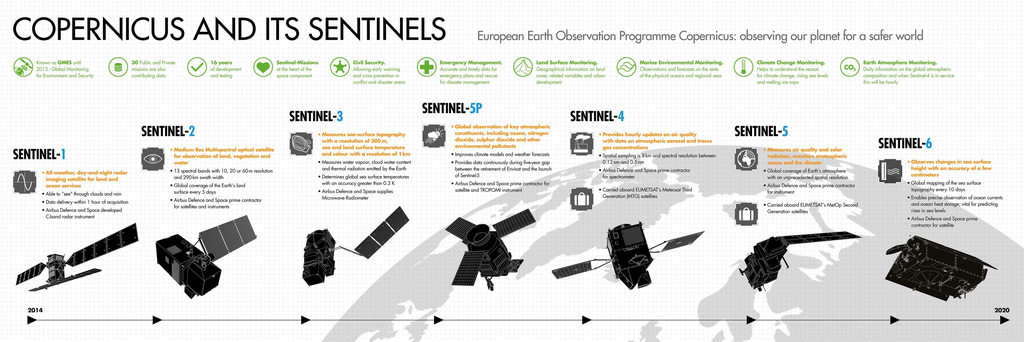

ESA - Satélites Copernicus Sentinel. Más información en: https://www.copernicus.eu/en/about-copernicus/infrastructure/discover-our-satellites

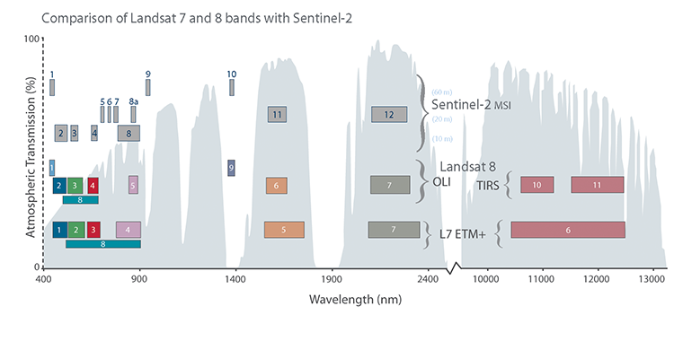

Distribución de bandas de Sentinel 2 comparadas con Landsat

### Niveles de procesamiento Sentinel 2

- **L1C**: Reflectancia a tope de atmósfera o Top of Atmosphere (TOA). Disponibles desde el lanzamiento.
- **L2A**: Reflectancia Superficial o Bottom of Atmosphere (BOA), i.e., los datos han sido corregidos para remover los efectos de la atmósfera. Sólo desde 2019.

**Importante**

**Long Term Archive (LTA)**

Todos los productos (1C o 2A) de más de un año son movidos fuera de línea y se requiere un tiempo de espera para ponerlos a disposición del usuario. Esto dificulta la automatización de tareas con productos de más de 12 meses de antigüedad.

## Extensiones de GRASS para datos Sentinel

- [i.sentinel.download](https://grass.osgeo.org/grass7/manuals/addons/i.sentinel.download.html): descarga productos Copernicus Sentinel de Copernicus Open Access Hub
- [i.sentinel.import](https://grass.osgeo.org/grass7/manuals/addons/i.sentinel.import.html): importa datos Sentinel descargados de Copernicus Open Access Hub
- [i.sentinel.preproc](https://grass.osgeo.org/grass7/manuals/addons/i.sentinel.preproc.html): importa y realiza corrección atmosférica y topográfica de imágenes S2
- [i.sentinel.mask](https://grass.osgeo.org/grass7/manuals/addons/i.sentinel.mask.html): crea máscaras de nubes y sombras para imágenes S2
- [i.sentinel.coverage](https://grass.osgeo.org/grass-stable/manuals/addons/i.sentinel.coverage.html): comprueba la cobertura de área de las escenas de S1 o S2 seleccionadas
- [i.sentinel.parallel.download](https://grass.osgeo.org/grass-stable/manuals/addons/i.sentinel.parallel.download.html): descarga imagenes Sentinel en paralelo

Para conectarse al [Copernicus Open Access Hub](https://scihub.copernicus.eu/) a través de [i.sentinel.download](https://grass.osgeo.org/grass7/manuals/addons/i.sentinel.download.html), se necesita ser usuario [registrado](https://scihub.copernicus.eu/dhus/#/self-registration).

Cada participante necesita registrarse y crear el archivo *`SENTINEL_SETTING.txt`* en el directorio *`$HOME/gisdata/`* con el siguiente contenido:

```
your_username
your_password
```

## Manos a la obra

### Iniciamos GRASS

Iniciar GRASS GIS, crear nuevo mapset y establecer región computacional

```python
import os

# data directory
homedir = "/content/drive/MyDrive/curso_grass_2023"

# GRASS GIS database variables
grassdata = os.path.join(homedir, "grassdata")
project = "posgar2007_4_cba"
mapset = "PERMANENT"
```

```python
import subprocess
import sys

# Ask GRASS GIS where its Python packages are to be able to start it from the notebook
sys.path.append(
    subprocess.check_output(["grass", "--config", "python_path"], text=True).strip()
)
```

```python
# Importar los paquetes python de GRASS
import grass.script as gs
import grass.jupyter as gj

# Iniciar GRASS
session = gj.init(grassdata, project, mapset)
```

Para trabajar con los datos de Sentinel 2 en esta sesión, creamos un nuevo mapset y lo llamamos **sentinel2**.

```python
# Create a new mapset
gs.run_command("g.mapset",
               mapset="sentinel2",
               flags="c")
```

```python
# Check accessible mapsets
gs.run_command("g.mapsets",
               flags="p")
```

Al igual que en la sesión anterior y como haremos cada vez que iniciemos un proyecto, primero definimos la región computacional. En este caso, vamos a usar el radio urbano de Córdoba que extrajimos en la sesión anterior.

```python
# Add mapset landsat8 to the path
gs.run_command("g.mapsets",
               mapset="landsat8",
               operation="add")
```

```python
# List vector maps
gs.list_grouped(type="vector")
```

```python
# set the computational region to the extent of Cordoba urban area
gs.run_command("g.region",
               vector="radio_urbano_cba",
               flags="p")
```

```python
# display radio_urbano_cba vector
cba_map = gj.InteractiveMap(width = 500, use_region=True, tiles="OpenStreetMap")
cba_map.add_vector("radio_urbano_cba")
cba_map.add_layer_control(position = "bottomright")
cba_map.show()
```

### Búsqueda y descarga de datos S2

Instalamos la caja de herramientas `i.sentinel` que consta de varios módulos que facilitan la búsqueda, filtrado, descarga, importación y pre-procesado de datos Sentinel, especialmente Sentinel 2, desde una sesión de GRASS GIS. Ver [i.sentinel](https://grass.osgeo.org/grass-stable/manuals/addons/i.sentinel.html) y los links de cada módulo para más detalles.

```python
# install extension - run only once
gs.run_command("g.extension",
               extension="i.sentinel")
```

Usamos el módulo `i.sentinel.download` que internamente utiliza la librería `sentinelsat` para buscar y filtrar escenas que contengan la región definida a partir del área urbana de la ciudad de Córdoba. Para esto necesitamos estar registrados en el [Copernicus hub](https://scihub.copernicus.eu/dhus/#/self-registration) y tener nuestras credenciales en un archivo de texto. Para más detalles sobre la función y sus usos, visitar el [manual](https://grass.osgeo.org/grass-stable/manuals/addons/i.sentinel.download.html).

```python
# list all available S2 level 2A scenes that meet the criteria specified
s2_credentials = os.path.join(homedir, "gisdata", "sentinel")
start_date = "2020-03-01"
end_date = "2020-04-30"

list_prod = gs.read_command("i.sentinel.download",
                            settings=s2_credentials,
                            start=start_date,
                            end=end_date,
                            producttype="S2MSI2A",
                            clouds=30,
                            area_relation="Contains",
                            footprints="s2_footprints",
                            flags="l")
```

```python
# print plain list
list_prod
```

Si con los criterios de búsqueda se encuentra una larga lista de productos, se puede usar la opción `limit` para controlar el número de escenas listadas.

```python
import pandas as pd
from io import StringIO

pd.read_csv(StringIO(list_prod), delimiter=" ", usecols=[0, 1, 2, 4, 5, 6, 7],
            names=['uuid', 'scene', 'date', 'cloud', 'product', 'size', 'unit'])
```

Mostramos los footprints de las escenas que encontramos según los criterios de búsqueda:

```python
# diplay footprints
cba_map = gj.InteractiveMap(width = 400, use_region=True, tiles="OpenStreetMap")
cba_map.add_vector("s2_footprints")
cba_map.add_layer_control(position = "bottomright")
cba_map.show()
```

Se observan 2 tipos de footprints: uno cuadrado y otro una pasada inclinada. Encontramos solo estos dos porque establecimos que nuestro *bounding box* (región computacional) debía estar **contenido** en la escena.

El próximo paso es descargar la escena o las escenas de interés. Para eso usamos nuevamente el módulo `i.sentinel.download`, pero sin el flag `l` de listar. Elegimos una imagen con nubes para demostrar posteriormente el uso de otro módulo del set de herramientas.

Como la descarga puede llevar bastante tiempo, **nos saltaremos esta parte** y utilizaremos directamente una escena ya descargada. Aún así, dejamos un ejemplo a continuación para referencia futura :)

```python
# download selected scene - esto toma tiempo y las escenas ya estan descargadas en la carpeta`s2_data`
s2_data = os.path.join(homedir, "gisdata", "s2_data")

# gs.run_command("i.sentinel.download",
#               settings=s2_credentials,
#               uuid="9a1ea49c-0561-4aa5-ba7a-dc820dc1a316",
#               output=s2_data)
```

### Importar datos Sentinel 2 a GRASS GIS

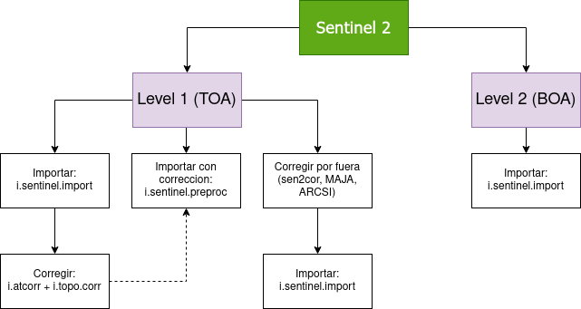

#### 1. Importar con corrección atmosférica

Si queremos importar con corrección atmosférica productos de nivel 1C, podemos usar el módulo [i.sentinel.preproc](https://grass.osgeo.org/grass-stable/manuals/addons/i.sentinel.preproc.html). Este módulo utiliza [i.atcorr](https://grass.osgeo.org/grass-stable/manuals/i.atcorr.html) internamente y necesita 2 inputs claves: un valor de aerosol optical depth (AOD) y un mapa de elevación.

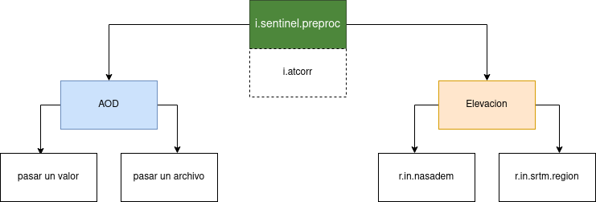

#### 2. Importar sin corrección atmosférica

Una vez descargada la escena deseada, se procede a importarla al mapset de trabajo. Para ello se usa el comando [i.sentinel.import](https://grass.osgeo.org/grass-stable/manuals/addons/i.sentinel.import.html) que permite subset, resampleo y reproyección al vuelo. Además, si en nuestra carpeta existen varios zip nos permite seleccionar, por medio de un patrón, cuáles queremos importar; y también, elegir solo las bandas de interés. Entonces, vamos a imprimir información sobre las bandas antes de importarlas.

```python
# print bands info before importing
# (1 -proj match, 0 -no proj match)
gs.run_command("i.sentinel.import",
               input=s2_data,
               flags="p")
```

```python
# import only bands relevant for RGB, NDVI and NDWI
gs.run_command("i.sentinel.import",
               input=s2_data,
               pattern_file="*20200330T141049*", # in case we have more s2 scenes in the s2_data folder
               pattern="B(02_1|03_1|04_1|08_1|8A_2|11_2|12_2)0m", # select bands and resolutions
               extent="region", # subset import to region extent
               flags="rcsj") # reproject, clouds, shadow, json metadata
```

Listamos los mapas importados:

```python
# list raster maps
lista = gs.list_grouped(type="raster")['sentinel2']
lista
```

A continuación, chequeamos los metadatos de uno de los mapas o bandas. Notar que todos los metadatos que vienen con la imagen original se agregan a la banda correspondiente en el momento de la importación. Esto es gracias al uso del flag `j` en el comando `i.sentinel.import`.

```python
# check metadata of some imported bands
gs.raster_info(map="T20JLL_20200330T141049_B03_10m")
```

Veamos los *semantic labels* de las bandas importadas:

```python
# print semantic labels of imported bands
for i in gs.list_grouped(type="raster")['sentinel2']:
    label = gs.raster_info(map=i)['semantic_label']
    print('Mapa: {}, Semantic label: {}'.format(i,label))
```

### Balance de colores y composiciones

A continuación, aplicamos la paleta de *grises* a las bandas R, G y B, mejoramos el contraste y las mostramos usando la clase `Map` de `grass.jupyter`.

```python
# apply grey color to RGB bands
gs.run_command("r.colors",
               map=lista,
               color="grey")
```

```python
# perform color auto-balancing for RGB bands
gs.run_command("i.colors.enhance",
               red="T20JLL_20200330T141049_B04_10m",
               green="T20JLL_20200330T141049_B03_10m",
               blue="T20JLL_20200330T141049_B02_10m",
               strength=90)
```

```python
# display the enhanced RGB combination
cba_rgb = gj.Map(use_region=True)
cba_rgb.d_rgb(red="T20JLL_20200330T141049_B04_10m",
              green="T20JLL_20200330T141049_B03_10m",
              blue="T20JLL_20200330T141049_B02_10m")
cba_rgb.d_grid(size=5000, flags="b")
cba_rgb.show()
```

**Tarea**

Realizar balance de colores y mostrar combinacion falso color NIR-RED-GREEN

### Identificación y enmascarado de nubes

Como empezaremos a generar mapas raster nuevos, es fundamental que establezcamos la región computacional a los límites y resolución de una de nuestras bandas. También podría ser que nos interesase un área más pequeña para hacer unas pruebas iniciales. Esto es sumamente facil y evita que tengamos que cortar raster a raster físicamente.

```python
# set comp reg to a band - all subsequent output rasters will have this extension & resolution
gs.parse_command("g.region",
                 raster="T20JLL_20200330T141049_B02_10m",
                 flags="g")
```

Ahora demostramos el uso del módulo [i.sentinel.mask](https://grass.osgeo.org/grass-stable/manuals/addons/i.sentinel.mask.html) que toma los metadatos registrados al importar las bandas para ejecutar la identificacion de nubes y sus sombras.

```python
# identify and mask clouds and clouds shadows: i.sentinel.mask
gs.run_command("i.sentinel.mask",
               blue="T20JLL_20200330T141049_B02_10m",
               green="T20JLL_20200330T141049_B03_10m",
               red="T20JLL_20200330T141049_B04_10m",
               nir="T20JLL_20200330T141049_B08_10m",
               nir8a="T20JLL_20200330T141049_B8A_20m",
               swir11="T20JLL_20200330T141049_B11_20m",
               swir12="T20JLL_20200330T141049_B12_20m",
               cloud_mask="cloud",
               shadow_mask="shadow",
               scale_fac=10000,
               flags="s",
               overwrite=True)
```

Por defecto obtenemos un mapa vectorial con contornos de nubes y otro para las sombras de nubes:

```python
# list vector maps in the mapset
gs.list_grouped(type="vector")['sentinel2']
```

Veamos el resultado agregando “capas” al mapa anterior:

```python
# display output
cba_rgb.d_vect(map="shadow", color="red", fill_color="red")
cba_rgb.d_vect(map="cloud", color="blue", fill_color="blue")
cba_rgb.show()
```

Inspeccionamos el mapa de nubes descargado con la escena (a traves de los flags `c` y `s`) y establecemos la misma paleta de colores a los fines de comparar ambos productos: la máscara de nubes y sombras obtenida con `i.sentinel.mask` y la provista por ESA junto con las imágenes.

```python
# utilizamos un comando de GRASS directamente
!v.db.select T20JLL_20200330T141049_MSK_CLOUDS | head
```

```python
# o su version dentro de la libreria grass.script
vec_attr_table = gs.vector_db_select("T20JLL_20200330T141049_MSK_CLOUDS")
```

```python
vec_attr_table["values"]
```

Asignamos la misma paleta de colores y visualizamos el resultado:

```python
s2_clouds = "T20JLL_20200330T141049_MSK_CLOUDS"
colours = ["1 0:0:255", "2 255:0:0"]
colourise = gs.feed_command("v.colors", map=s2_clouds, use="attr", column="value", rules="-", quiet=True)
colourise.stdin.write("\n".join(colours).encode())
colourise.stdin.close()
```

```python
cba_rgb = gj.Map(use_region=True)
cba_rgb.d_rgb(red="T20JLL_20200330T141049_B04_10m",
              green="T20JLL_20200330T141049_B03_10m",
              blue="T20JLL_20200330T141049_B02_10m")
cba_rgb.d_grid(size=5000, flags="b")
cba_rgb.d_vect(map="T20JLL_20200330T141049_MSK_CLOUDS")
cba_rgb.show()
```

Los resultados son bastante parecidos y en este último caso, no necesitariamos ejecutar un segundo comando. No obstante, tanto `i.sentinel.mask` como la banda que viene con la escena, tienen opciones para ajustar el tamaño de nubes y sombras identificadas que aquí se dejaron por defecto.

### Indices espectrales de vegetación y agua

Antes de proceder a calcular los índices, vamos a enmascarar las áreas identificadas como nubes y sombras. Para eso, primero pegamos los vectores en uno solo y luego lo aplicamos como máscara inversa. Para más detalles del funcionamiento de las máscaras en GRASS ver [r.mask](https://grass.osgeo.org/grass-stable/manuals/r.mask.html).

```python
# set clouds mask
gs.run_command("v.patch",
               input="cloud,shadow",
               output="cloud_shadow_mask")

gs.run_command("r.mask",
               vector="cloud_shadow_mask",
               flags="i")
```

Luego utilizamos los módulos [i.vi](https://grass.osgeo.org/grass-stable/manuals/i.vi.html) e [i.wi](https://grass.osgeo.org/grass-stable/manuals/addons/i.wi.html) (addon) para estimar NDVI y NDWI. Ver los respectivos manuales para más detalles sobre los índices disponibles.

```python
# estimate vegetation indices
gs.run_command("i.vi",
               red="T20JLL_20200330T141049_B04_10m",
               nir="T20JLL_20200330T141049_B08_10m",
               output="T20JLL_20200330T141049_NDVI_10m",
               viname="ndvi")

# add semantic label
gs.run_command("r.support",
               map="T20JLL_20200330T141049_NDVI_10m",
               semantic_label="NDVI")
```

```python
# install extension
gs.run_command("g.extension",
               extension="i.wi")
```

```python
# estimate water indices and set color palette
gs.run_command("i.wi",
               green="T20JLL_20200330T141049_B03_10m",
               nir="T20JLL_20200330T141049_B08_10m",
               output="T20JLL_20200330T141049_NDWI_10m",
               winame="ndwi_mf")

# add semantic label
gs.run_command("r.support",
               map="T20JLL_20200330T141049_NDWI_10m",
               semantic_label="NDWI")

# set ndwi color table
gs.run_command("r.colors",
               map="T20JLL_20200330T141049_NDWI_10m",
               color="ndwi")
```

```python
# interactive maps
idx_map = gj.InteractiveMap(width = 400, use_region=True, tiles="OpenStreetMap")
idx_map.add_raster("T20JLL_20200330T141049_NDVI_10m", opacity=0.7)
idx_map.add_raster("T20JLL_20200330T141049_NDWI_10m", opacity=0.7)
idx_map.add_layer_control(position = "bottomright")
idx_map.show()
# ... use the layer selector in the corner to enable/disable the NDVI/NDWI layers
```

### Mapas de GRASS como arrays de Numpy

Los mapas de GRASS pueden leerse como arrays de Numpy gracias a la funcion `array` de la librería *grass.script*. Esto facilita muchas operaciones posteriores con librerías de Python que requieren un array como input. En este caso, demostramos su uso con un histograma.

```python
# Import required libraries
import numpy as np
import seaborn as sns
import matplotlib.pyplot as plt
from grass.script import array as garray

# Read NDVI as numpy array
ndvi = garray.array(mapname="T20JLL_20200330T141049_NDVI_10m", null="nan")
ndwi = garray.array(mapname="T20JLL_20200330T141049_NDWI_10m", null="nan")
print(ndvi.shape,ndwi.shape)
```

```python
# Plot NDVI and NDWI
sns.set_style('darkgrid')
fig, axs = plt.subplots(1, 2, figsize=(7, 7))
sns.histplot(ax=axs[0], data=ndvi.ravel(), kde=True, color="olive")
sns.histplot(ax=axs[1], data=ndwi.ravel(), kde=True, color="skyblue")
plt.show()
```

```python
plt.imshow(ndvi, cmap="Greens")
```

### Segmentación

Existen varios módulos para relizar segmentación en GRASS GIS, los mas conocidos son [i.segment](https://grass.osgeo.org/grass80/manuals/i.segment.html) e [i.superpixels.slic](https://grass.osgeo.org/grass80/manuals/addons/i.superpixels.slic.html). Vamos a demostrar su uso.

Primero, instalamos la extensión *i.superpixels.slic*.

```python
# install extension
gs.run_command("g.extension",
               extension="i.superpixels.slic")
```

Luego, listamos los mapas y crear el grupo con las bandas y los índices.

```python
# list maps
s2_maps = gs.list_grouped(type="raster",
                          pattern="*20200330T141049*")['sentinel2']
print(s2_maps)
```

```python
# create group and subgroup with bands and indices
gs.run_command("i.group",
               group="s2",
               subgroup="s2",
               input=s2_maps)

gs.parse_command("i.group",
                 group="s2",
                 flags="l")
```

Ejecutar *i.superpixels.slic* y convertir el resultado a vector

```python
# run i.superpixels.slic
gs.run_command("i.superpixels.slic",
               input="s2",
               output="superpixels",
               num_pixels=50)
```

```python
# convert the resulting raster to vector
gs.run_command("r.to.vect",
               input="superpixels",
               output="superpixels",
               type="area")
```

Ejecutar *i.segment* y convertir el resultado a vector

```python
# run i.segment (region growing)
gs.run_command("i.segment",
               group="s2",
               output="segments",
               threshold=0.5,
               minsize=50,
               memory=500)
```

```python
# convert the resulting raster to vector
gs.run_command("r.to.vect",
               input="segments",
               output="segments",
               type="area")
```

Comparamos el número de segmentos obtenidos:

```python
# compare number of segments
n1 = gs.vector_info(map="superpixels")['areas']
n2 = gs.vector_info(map="segments")['areas']

print("Superpixels SLIC: {}\nRegion growing: {}".format(n1,n2))
```

```python
# diplay results
seg_map = gj.InteractiveMap(width = 600, use_region=True, tiles="OpenStreetMap")
seg_map.add_vector("superpixels")
seg_map.add_vector("segments")
seg_map.add_layer_control(position = "bottomright")
seg_map.show()

#... si tarda mucho en ejecutar dentro de Colab, usar la class `Map`
```

**Tarea**

Ejecutar cualquiera de los 2 métodos de segmentación con diferentes parámetros y comparar los resultados

### Clasificación supervisada

#### Clasificación supervisada con Maximum Likelihood

Vamos a demostrar a continuacion el workflow para realizar una clasificacion supervisada por máxima verosimilitud a partir de unos polígonos de entrenamiento digitalizados en GRASS y que se encuentran en la carpeta `s2_data`.

Importamos el vector y lo visualizamos.

```python
train_areas = os.path.join(homedir, s2_data, "training.gpkg")
```

```python
# import gpkg with training areas
gs.run_command("v.import",
               input=train_areas,
               output="training")
```

```python
# use color column for classes
gs.run_command("v.colors",
               map="training",
               rgb_column="color",
               flags="c")
```

```python
# map
cba_rgb_train = gj.Map(width=300, use_region=True)
cba_rgb_train.d_rgb(red="T20JLL_20200330T141049_B04_10m",
              green="T20JLL_20200330T141049_B03_10m",
              blue="T20JLL_20200330T141049_B02_10m")
cba_rgb_train.d_grid(size=5000, fontsize=7, flags="b")
cba_rgb_train.d_vect(map="training")
cba_rgb_train.show()
```

Convertimos el mapa vectorial con los polígonos de entrenamiento a mapa raster. Para ello, utilizamos la columna que contiene los números de clase.

```python
!v.db.select training | head
```

```python
# convert to raster
gs.run_command("v.to.rast",
               input="training",
               output="training",
               use="attr",
               attribute_column="cat_",
               label_column="class")
```

A continuación, utilizamos el módulo [i.gensig](https://grass.osgeo.org/grass-stable/manuals/i.gensig.html) para generar las firmas espectrales de las clases de interés a partir de los polígonos conocidos/etiquetados.

```python
# obtain signature files
gs.run_command("i.gensig",
               trainingmap="training",
               group="s2",
               subgroup="s2",
               signaturefile="sig_sentinel")
```

El archivo de firmas es un archivo de texto que se guarda automáticamente dentro de la carpeta `grassdata/posgar2007_4_cba/sentinel2/signatures/sig/sig_sentinel/` y tiene la siguiente forma:

```
1
#
S2_2 S2_3 S2_4 S2_8 S2_11 S2_12 S2_8A NDVI NDWI
#class_1
34976
462.107 754.712 650.115 2652.12 2328.17 1354.23 2898.15 0.590024 -0.54825
3433.54
3439.85 13667.9
4587.72 3893.81 16344.2
-891.313 51917 -46133.6 508644
6381.57 8558.14 18795.3 -11728.6 64026.7
5455.05 4485.2 19848.3 -53771.7 37873.6 35044.9
-1286.3 52732.6 -45664.8 513310 -5531.12 -52538.1 526931
-1.76356 3.82015 -10.8837 64.4926 -9.11136 -12.7041 64.3455 0.0108229
1.38826 -0.0813683 6.12975 -29.5299 4.5855 6.97446 -29.4906 -0.00517479 0.00292289
#class_2
37706
1609.95 1825.69 1919.19 2607.13 2801.12 2369.91 2765.3 0.160587 -0.184169
234001
240075 251609
248408 260806 281060
151243 167006 169635 212669
123807 133556 145512 127378 164973
116139 123360 136440 90707.7 153127 163716
93815.4 104574 105790 153545 118673 82117.3 147388
-33.6194 -33.5942 -38.5054 -0.417204 -11.895 -16.7121 3.63643 0.0104315
33.4993 33.3665 35.3967 1.58334 9.64074 13.9172 -2.8798 -0.00928648 0.00896403
#class_3
13363
744.78 937.046 1247.71 1824.1 3187.07 2764.02 2009.06 0.191184 -0.325633
27636.3
34766.2 44710.3
42545.7 55127.4 70153.9
50592 65854 81541.4 102364
39674.6 49909.5 66588.2 79876.4 180631
38446.9 49209.5 64455.1 73554.7 120268 105226
49526.6 64512.1 80082.1 100116 81815.5 74146.1 99653.8
-3.37419 -4.24876 -5.95143 -4.94336 -5.45999 -6.25113 -5.00936 0.0010409
4.3353 5.42295 6.64764 6.64209 5.19235 6.46732 6.6178 -0.000876728 0.00103444
```

donde:

```
    Line 1: version number (currently always 1)
    Line 2: text label
    Line 3: Space separated list of semantic labels
    Line 4: text label of class
    Line 5: number of points in class
    Line 6: mean values per band of the class
    Line 7-15: (semi)-matrix of band-band covariance
```

Para realizar la clasificación supervisada por máxima verosimilitud, el módulo [i.maxlik](https://grass.osgeo.org/grass-stable/manuals/i.maxlik.html) toma el grupo y la firma como principales inputs:

```python
# perform ML supervised classification
gs.run_command("i.maxlik",
               group="s2",
               subgroup="s2",
               signaturefile="sig_sentinel",
               output="sentinel_maxlik")
```

Asignamos etiquetas a las clases y visualizamos el resultado.

```python
# label classes
label_class = ["1:vegetation", "2:urban", "3:bare soil"]
categorise = gs.feed_command("r.category",
                             map="sentinel_maxlik",
                             separator=":",
                             rules="-",
                             quiet=True)
categorise.stdin.write("\n".join(label_class).encode())
categorise.stdin.close()
```

```python
# display results
cba_sup_class = gj.Map(width=500, use_region=True)
cba_sup_class.d_rast(map="sentinel_maxlik")
cba_sup_class.d_legend(raster="sentinel_maxlik", title="Class", fontsize=10, at=(80, 93, 80, 90), flags="b")
cba_sup_class.d_barscale()
cba_sup_class.show()
```

#### Estadísticas por clase

Utilizamos el comando [r.report](https://grass.osgeo.org/grass-stable/manuals/r.report.html) para obtener la proporción de cada clase, incluida la de celdas sin datos debido al enmascarado de nubes y sombras de nubes.

```python
# porcentaje de cada clase
gs.parse_command("r.report",
                 map="sentinel_maxlik",
                 units="p",
                 flags="h")
```

A continuación, usamos el módulo [r.univar](https://grass.osgeo.org/grass-stable/manuals/r.univar.html) para obtener estadísticas descriptivas por clase para la variable NDVI. Para esto, además del raster de NDVI, se pasa la clasificación. Así, el módulo calcula las estadísticas para cada clase.

```python
# estadisticas de las clases: NDVI
class_stats = gs.read_command("r.univar",
                              map="T20JLL_20200330T141049_NDVI_10m",
                              zones="sentinel_maxlik",
                              flags="t")
class_stats_df = pd.DataFrame([line.split("|") for line in class_stats.splitlines()])
class_stats_df.columns = class_stats_df.iloc[0]
```

```python
df2 = class_stats_df.loc[1:,['label', 'min', 'max', 'mean']] # selecciono unicamente min, max mean
df2
```

#### Clasificación supervisada con Machine Learning

Primero tenemos que instalar la extensión [r.learn.ml2](https://grass.osgeo.org/grass-stable/manuals/addons/r.learn.ml2.html) que consta de dos módulos: `r.learn.train` y `r.learn.predict`. Esta extensión utiliza la librería scikit-learn de Python y requiere que la misma esté instalada de antemano.

```python
# install ML extension
gs.run_command("g.extension",
               extension="r.learn.ml2")
```

Ahora entrenamos el modelo ML usando [r.learn.train](https://grass.osgeo.org/grass-stable/manuals/addons/r.learn.train.html), con el modelo “RandomForestClassifier”.

```python
# train a random forest classification model using r.learn.train
gs.run_command("r.learn.train",
               group="s2",
               training_map="training",
               model_name="RandomForestClassifier",
               n_estimators="500",
               save_model=os.path.join(homedir, "rf_model.gz"))
```

El modelo se ha almacenado en el archivo `rf_model.gz` para su uso en el paso de predicción de la clasificación supervisada.

Ahora entonces aplicamos el modelo entrenado a todo el conjunto de datos.

```python
# Perform prediction using r.learn.predict
gs.run_command("r.learn.predict",
               group="s2",
               load_model=os.path.join(homedir, "rf_model.gz"),
               output="sentinel_rf")
```

```python
# label classes
label_class = ["1:vegetation", "2:urban", "3:bare soil"]
categorise = gs.feed_command("r.category",
                             map="sentinel_rf",
                             separator=":",
                             rules="-",
                             quiet=True)
categorise.stdin.write("\n".join(label_class).encode())
categorise.stdin.close()
```

```python
# display results
cba_sup_class = gj.Map(width=500, use_region=True)
cba_sup_class.d_rast(map="sentinel_rf")
cba_sup_class.d_legend(raster="sentinel_rf", title="Class", fontsize=10, at=(80, 93, 80, 90), flags="b")
cba_sup_class.d_barscale()
cba_sup_class.show()
```

**Tarea**

Estimar estadísticas por clase al igual que hicimos para la clasificación por maxíma verosimilitud.

Comparemos los resultados visualmente y con el módulo [r.coin](https://grass.osgeo.org/grass-stable/manuals/r.coin.html), que nos permite tabular la ocurrencia mutua o coincidencia entre las categorías de dos mapas ráster.

```python
# Display both classified maps together
clas_maps = gj.InteractiveMap(width = 600, tiles="OpenStreetMap")
clas_maps.add_raster("sentinel_maxlik", opacity=0.7)
clas_maps.add_raster("sentinel_rf", opacity=0.7)
clas_maps.add_layer_control(position = "bottomright")
clas_maps.show()
```

```python
print(gs.read_command("r.coin",
                      first="sentinel_maxlik",
                      second="sentinel_rf",
                      units="p",
                      flags="w"))
```

**Tarea**

Comparar los resultados de ambos tipos de clasificación supervisada a través del índice Kappa.

### Post-procesamiento y validación

- [r.reclass.area](http://grass.osgeo.org/grass-stable/manuals/r.reclass.area.html) para eliminar pequeñas áreas, enmascarar nuevos valores y rellenar los huecos con [r.neighbors](http://grass.osgeo.org/grass-stable/manuals/r.neighbors.html) o [r.fillnulls](http://grass.osgeo.org/grass-stable/manuals/r.fillnulls.html)
- convertir la salida en vector y ejecutar [v.clean](http://grass.osgeo.org/grass-stable/manuals/v.clean.html) con `tool=rmarea`
- [r.kappa](https://grass.osgeo.org/grass-stable/manuals/r.kappa.html) para la validación (idealmente también digitalizar una muestra de prueba)